# Exploration of the Exponential Distribution

Bojan Zunar

14 July 2018

# 1 Simulation of the exponential distribution

In this project we investigate the exponential distribution and compare it to the Central Limit Theorem. We expect that the mean of exponential distribution will converge to `1/lambda`. The standard deviation should also converge to `1/lambda`.

The exponential distribution is simulated with function `rexp` where `lambda` is the rate parameter set to 0.2. We investigate the distribution of averages of 40 exponentials by performing a thousand simulations and then for each simulated sample calculate mean, normalised mean, and variance.

```r
library(magrittr); library(ggplot2); library(dplyr); library(purrr); library(ggsci)

set.seed(12345)
lambda <- 0.2; n <- 40; B <- 1000

rexponentials <- matrix(rexp(n * B, lambda), nrow = B, ncol = n, byrow = TRUE)

averages <- rexponentials %>%
    apply(1, function(x) {
        mean <- mean(x)
        mean_norm <- (mean(x)-1/lambda)/((1/lambda)/sqrt(40))
        variance <- var(x)
        c(mean, mean_norm, variance)
        }) %>%
    t %>%
    as.data.frame %>%
    set_names("mean", "mean_norm", "variance")
```

# 2 Sample mean vs theoretical mean of the distribution

First, we explore the sample mean and compare it with the theoretical mean of the exponential distribution. We plot the histogram of the averages of 40 random exponentials, mean of the sample averages (vertical read line), and expected theoretical mean (`1/lambda = 1/0.2 = 5`, vertical blue line).

**Theoretical mean agrees with the mean of the obtained sample averages.**

```r
cat("Theoretical mean:", 1/lambda, "\t Mean of averages:", mean(averages$mean))
```

```
## Theoretical mean: 5   Mean of averages: 4.971972
```

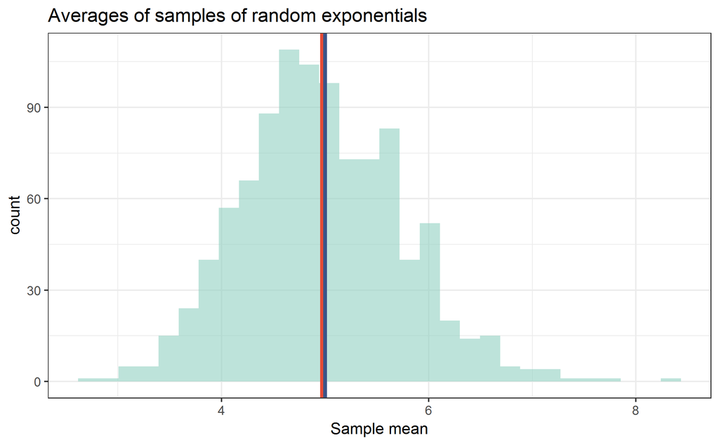

```r
ggplot(data = averages, aes(averages$mean)) +
    geom_histogram(fill = pal_npg("nrc", alpha = 0.6)(10)[7]) +
    labs(title = "Averages of samples of random exponentials") +
    labs(x = "Sample mean") +
    theme_bw() +
    geom_vline(xintercept = mean(averages$mean), size = 1.5,
               color = pal_npg("nrc")(4)[1]) +
    geom_vline(xintercept = 1/lambda, size = 1.25,
               color = pal_npg("nrc")(4)[4])
```

# 3 Sample variance vs theoretical variance of the distribution

**Theoretical variance agrees with the variance of samples of random exponentials.**

```r
cat("Theoretical variance:", (1/lambda)^2,
    "\t Mean variance of averages:", mean(averages$variance))
```

```
## Theoretical variance: 25      Mean variance of averages: 24.58892
```

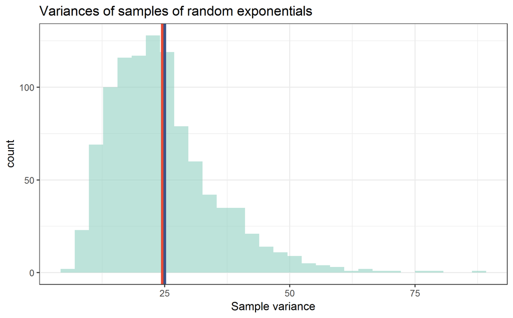

```r
ggplot(data = averages, aes(averages$variance)) +
    geom_histogram(fill = pal_npg("nrc", alpha = 0.6)(10)[7]) +
    labs(title = "Variances of samples of random exponentials") +
    labs(x = "Sample variance") +
    theme_bw() +
    geom_vline(xintercept = mean(averages$variance), size = 1.5,
               color = pal_npg("nrc")(4)[1]) +
    geom_vline(xintercept = (1/lambda)^2, size = 1.25,
               color = pal_npg("nrc")(4)[4])
```

# 4 Normality of the means of random exponentials

We show that normalised means of random exponentials approximately follow the standard normal distribution. This observation is not valid in the case of normalised random exponentials.

Histograms show probability density functions of normalised random exponentials and sample means of 40 random exponentials. The blue curve denotes the probability density function of standardised normal distribution.

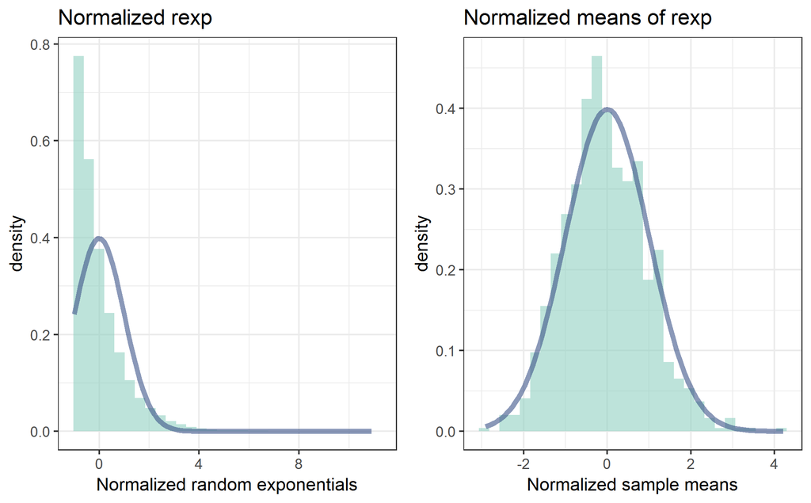

```r
g1 <- rexponentials %>%
    apply(1, function(x) {
        rexp_norm <- (x-1/lambda)/((1/lambda)/sqrt(1))
        c(rexp_norm)
    }) %>% t %>% as.vector %>% as.data.frame() %>%
    ggplot(aes(.)) +
    geom_histogram(aes(y = ..density..), fill = pal_npg("nrc", alpha = 0.6)(10)[7]) +
    labs(title = "Normalized rexp") +
    labs(x = "Normalized random exponentials") +
    theme_bw() +
    stat_function(fun = dnorm, size = 1.5, color = pal_npg("nrc", alpha = 0.6)(4)[4])

ggnorm <- ggplot(data = averages, aes(averages$mean_norm)) +
    geom_histogram(aes(y = ..density..), fill = pal_npg("nrc", alpha = 0.6)(10)[7]) +
    labs(title = "Normalized means of rexp") +
    labs(x = "Normalized sample means") +
    theme_bw() +
    stat_function(fun = dnorm, size = 1.5, color = pal_npg("nrc", alpha = 0.6)(4)[4])

multiplot(g1, ggnorm, cols = 2)
```

# 5 Conclusion

Means of random exponentials approximately follow a normal distribution. Distribution of the normalised sample means is centred at zero, and approximately 95% of values fall between [-2,2].